# Hong Kong SARS-CoV-2 Pandemic Trend Analysis

## About

This document is a simple data analysis of SARS-CoV-2 Pandemic in Hong Kong. This notebook serves to analyze and visualize the progress of the pandemic from two datasets and various perspectives.

**Note** In Jupyter notebooks and lab, you can see the documentation for a python function by hitting ``SHIFT + TAB``. Hit it twice to expand the view.

```python
import pandas as pd
from matplotlib import pyplot as plt
from matplotlib import dates as mpl_dates
```

In the tutorial, we obtain the 'Latest situation of reported cases of COVID-19' in Hong Kong data through [data.gov.hk](https://data.gov.hk/en-data/dataset/hk-dh-chpsebcddr-novel-infectious-agent), which holds various important data related to the Coronavirus Disease (COVID-19). We apply the [pandas](https://pandas.pydata.org/) package, which is a fast and easy-to-use data analysis tool for Python programming language, to manipulate the table contents. In this step, we read the data table into an [DataFrame](https://pandas.pydata.org/docs/reference/api/pandas.DataFrame.html) object named 'df_hk_covid', which is a two-dimensional, size-mutable, potentially heterogeneous tabular data.

```python
df_hk_covid = pd.read_csv('http://www.chp.gov.hk/files/misc/latest_situation_of_reported_cases_covid_19_eng.csv')
```

```python
df_hk_covid
```

|  | As of date | As of time | Number of confirmed cases | Number of ruled out cases | Number of cases still hospitalised for investigation | Number of cases fulfilling the reporting criteria | Number of death cases | Number of discharge cases | Number of probable cases | Number of hospitalised cases in critical condition |
| --- | --- | --- | --- | --- | --- | --- | --- | --- | --- | --- |
| 0 | 08/01/2020 | 12:00 | 0 | 21.0 | 17.0 | 38.0 | 0 | 0 | 0 | NaN |
| 1 | 09/01/2020 | 12:00 | 0 | 25.0 | 23.0 | 48.0 | 0 | 0 | 0 | NaN |
| 2 | 10/01/2020 | 12:00 | 0 | 31.0 | 23.0 | 54.0 | 0 | 0 | 0 | NaN |
| 3 | 11/01/2020 | 12:00 | 0 | 46.0 | 15.0 | 61.0 | 0 | 0 | 0 | NaN |
| 4 | 12/01/2020 | 12:00 | 0 | 51.0 | 16.0 | 67.0 | 0 | 0 | 0 | NaN |
| ... | ... | ... | ... | ... | ... | ... | ... | ... | ... | ... |
| 599 | 29/08/2021 | NaN | 12107 | NaN | NaN | NaN | 212 | 11783 | 1 | 0.0 |
| 600 | 30/08/2021 | NaN | 12110 | NaN | NaN | NaN | 212 | 11786 | 1 | 0.0 |
| 601 | 31/08/2021 | NaN | 12112 | NaN | NaN | NaN | 212 | 11791 | 1 | 0.0 |
| 602 | 01/09/2021 | NaN | 12113 | NaN | NaN | NaN | 212 | 11798 | 1 | 0.0 |
| 603 | 02/09/2021 | NaN | 12113 | NaN | NaN | NaN | 212 | 11799 | 1 | 0.0 |

604 rows × 10 columns

From the cell above, we can see an overview of the data table, including the number of rows, number of columns, name of rows, contents in the first 5 rows, and contents in the last five rows. We can further investigate the information of a DataFrame object through the [pandas.DataFrame.info](https://pandas.pydata.org/docs/reference/api/pandas.DataFrame.info.html) function.

```python
df_hk_covid.info()
```

```
<class 'pandas.core.frame.DataFrame'>
RangeIndex: 604 entries, 0 to 603
Data columns (total 10 columns):
 #   Column                                                Non-Null Count  Dtype
---  ------                                                --------------  -----
 0   As of date                                            604 non-null    object
 1   As of time                                            194 non-null    object
 2   Number of confirmed cases                             604 non-null    int64
 3   Number of ruled out cases                             89 non-null     float64
 4   Number of cases still hospitalised for investigation  89 non-null     float64
 5   Number of cases fulfilling the reporting criteria     89 non-null     float64
 6   Number of death cases                                 604 non-null    int64
 7   Number of discharge cases                             604 non-null    int64
 8   Number of probable cases                              604 non-null    int64
 9   Number of hospitalised cases in critical condition    515 non-null    float64
dtypes: float64(4), int64(4), object(2)
memory usage: 47.3+ KB
```

The cell above shows the column index (#), column name (Column), number of non-missing values of a column (Non-Null Count), and the variable type of the column (Dtype). That information is helpful for the further analysis of the data.

## Preprocessing

Before the analysis, we need to perform some pre-processing to transform the date in the DataFrame to a format that the machine can recognize through the function pandas.to_datetime.

```python
df_hk_covid['As of date'] = pd.to_datetime(df_hk_covid['As of date'],dayfirst=True)
```

On the cell above, we select a column through the operation: "df_hk_covid['As of date']". This operation will return a list of content in the selected column. You can select your own column of interest by replacing 'As of date' with other column names. Afterward, the content within the column is transformed into a novel datetime64 formate by the function pandas.to_datetime. We then replace the content in the 'As of date' column with a new format.

```python
df_hk_covid.info()
```

```
<class 'pandas.core.frame.DataFrame'>
RangeIndex: 604 entries, 0 to 603
Data columns (total 10 columns):
 #   Column                                                Non-Null Count  Dtype
---  ------                                                --------------  -----
 0   As of date                                            604 non-null    datetime64[ns]
 1   As of time                                            194 non-null    object
 2   Number of confirmed cases                             604 non-null    int64
 3   Number of ruled out cases                             89 non-null     float64
 4   Number of cases still hospitalised for investigation  89 non-null     float64
 5   Number of cases fulfilling the reporting criteria     89 non-null     float64
 6   Number of death cases                                 604 non-null    int64
 7   Number of discharge cases                             604 non-null    int64
 8   Number of probable cases                              604 non-null    int64
 9   Number of hospitalised cases in critical condition    515 non-null    float64
dtypes: datetime64[ns](1), float64(4), int64(4), object(1)
memory usage: 47.3+ KB
```

```python
# Extract the date column
dates = df_hk_covid['As of date']
latest_date = dates.max()
latest_date
```

```
Timestamp('2021-09-02 00:00:00')
```

```python
idx_latest_date = df_hk_covid['As of date']==dates.max()
idx_latest_date
```

```
0      False
1      False
2      False
3      False
4      False
       ...
599    False
600    False
601    False
602    False
603     True
Name: As of date, Length: 604, dtype: bool
```

Therefore, we can find out the row having the latest record and store its index in 'idx_latest_date'.

## Viusual analysis of the number of SARS-CoV-2 cases over time

To visualize the number of SARS-CoV-2 cases over time, we select a column ''Number of confirmed cases' as follows:

```python
total_cases = df_hk_covid['Number of confirmed cases']
```

We also extract the latest number of confirmed cases as follows:

```python
latest_total_cases = int(df_hk_covid.loc[idx_latest_date,'Number of confirmed cases'])
```

Here, we apply [pandas.DataFrame.loc](https://pandas.pydata.org/docs/reference/api/pandas.DataFrame.loc.html) to access a group of rows and columns by a specific condition. The condition of a row is the last day of the table, and the condition of the column is to select the number of confirmed cases. Therefore, we select the number of confirmed cases on the last day of the table. We apply the function int() to transform our query result to an integer.

Then, we visualize the Accumulated SARS-CoV-2 Cases in Hong Kong by Time as a line plot as follows:

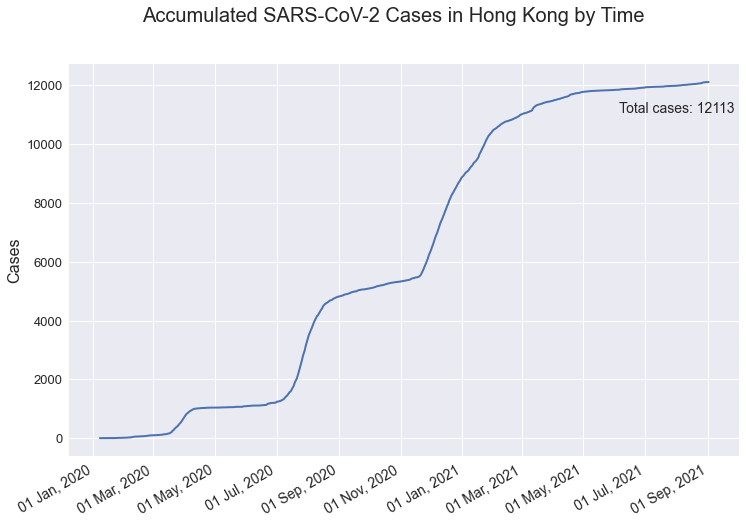

```python
# Configure figure style and size
plt.style.use('seaborn')
plt.figure(figsize=(12,8))

# Plot the figure
plt.plot(dates, total_cases.values, linewidth=2)

# Format the date in the x-axis
plt.gcf().autofmt_xdate()
date_format = mpl_dates.DateFormatter('%d %b, %Y')
plt.gca().xaxis.set_major_formatter(date_format)

# Plot axis and titles
plt.xlabel('')
plt.ylabel('Cases',fontsize=16)
plt.xticks(fontsize=14)
plt.yticks(fontsize=13)
plt.suptitle('Accumulated SARS-CoV-2 Cases in Hong Kong by Time', fontsize=20)

# Plot annotation of the latest case number
plt.annotate(text="Total cases: "+str(latest_total_cases), xy=(latest_date,latest_total_cases),
             xycoords='data', xytext=(-90,-30), textcoords='offset points', fontsize=14)
plt.show()
```

## Visual analysis of the daily cases of SARS-CoV-2

In this analysis, we would like to visualize the daily confirmed cases of SARS-CoV-2 in Hong Kong. However, the data table provided does not directly include the information. Therefore, we apply [pandas.DataFrame.diff](https://pandas.pydata.org/docs/reference/api/pandas.DataFrame.diff.html) to calculates the difference between the count of the confirmed case compared to the number in the previous row as follow:

```python
df_hk_covid['Number of daily confirmed cases'] = df_hk_covid["Number of confirmed cases"].diff().fillna(0).astype(int)
daily_cases = df_hk_covid['Number of daily confirmed cases']
```

In the previous cell, we also applied [pandas.DataFrame.fillna](https://pandas.pydata.org/docs/reference/api/pandas.DataFrame.fillna.html) because the first row of the data does not have a difference compared to the previous row. Then we applied [pandas.DataFrame.astype](https://pandas.pydata.org/docs/reference/api/pandas.DataFrame.astype.html) to define that our calculated results are integers.

Afterward, we select the latest number of new cases and the peak number of the daily case by [pandas.DataFrame.max](https://pandas.pydata.org/docs/reference/api/pandas.DataFrame.max.html) to make some annotation on our line plot:

```python
today_cases = int(df_hk_covid.loc[idx_latest_date, 'Number of daily confirmed cases'])
max_cases = int(df_hk_covid.loc[:,'Number of daily confirmed cases'].max())
```

Then, we visualize the SARS-CoV-2 Daily Confirmed Cases in Hong Kong as a line plot as follows:

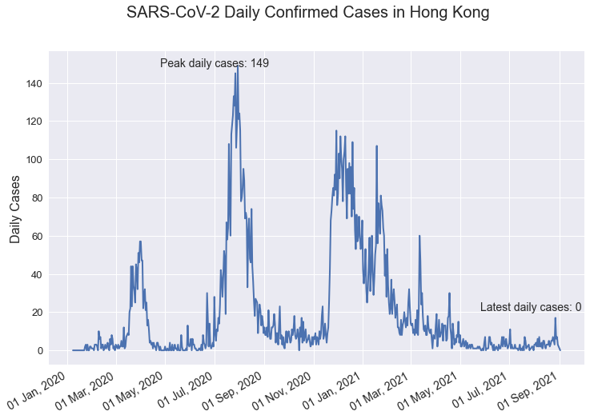

```python
# Configure figure style and size
plt.figure(figsize=(12,8))

# Plot the figure
plt.plot(dates, daily_cases,'-', linewidth=2)

# Format the date in the x-axis
plt.gcf().autofmt_xdate()
date_format = mpl_dates.DateFormatter('%d %b, %Y')
plt.gca().xaxis.set_major_formatter(date_format)

# Plot axis and titles
plt.xlabel('')
plt.xticks(fontsize=14)
plt.yticks(fontsize=13)
plt.ylabel('Daily Cases',fontsize=16)
plt.suptitle('SARS-CoV-2 Daily Confirmed Cases in Hong Kong',fontsize=20)

# Plot annotation of the latest case number
plt.annotate(text="Latest daily cases: "+str(today_cases), xy=(latest_date, today_cases),
             xycoords='data', xytext=(-100,50), textcoords='offset points', fontsize=14)
plt.annotate(text="Peak daily cases: "+str(max_cases), xy=(latest_date, today_cases),
             xycoords='data', xytext=(-500,355), textcoords='offset points', fontsize=14)

plt.show()
```

## Viusual analysis of the active cases of SARS-CoV-2

The number of active SARS-CoV-2 cases is neither provided in the dataset. By definition, the "number of active cases" should be the Number of confirmed cases - the Number of death cases - the "Number of discharge cases. In this time, we would like to visualize the trend of active cases of SARS-CoV-2 in Hong Kong in an alternative way. First of all, we calculated the number of active cases as follows:

```python
df_hk_covid['Number of active cases'] = df_hk_covid['Number of confirmed cases']-df_hk_covid['Number of death cases']-df_hk_covid['Number of discharge cases']
```

Likewise, we select the latest records to make some annotation on our stack plot:

```python
latest_active_cases = int(df_hk_covid.loc[idx_latest_date,"Number of active cases"])
latest_death_cases = int(df_hk_covid.loc[idx_latest_date,'Number of death cases'])
latest_discharge_cases = int(df_hk_covid.loc[idx_latest_date,'Number of discharge cases'])
```

The trend of SARS-CoV-2 Active Cases in Hong Kong as a stack plot is then shown as follows:

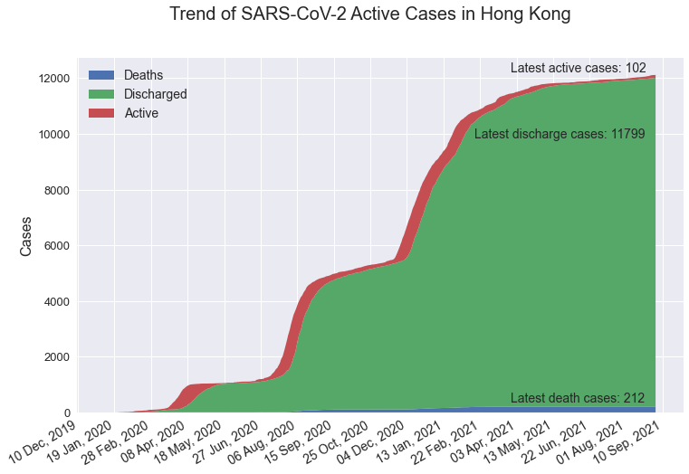

```python
# For stack plots, we need to generate subplots
fig, ax = plt.subplots()

# Configure figure style and size
fig.set_figheight(8)
fig.set_figwidth(12)

# Define labels to show on the plot
labels = ['Deaths','Discharged','Active']

# Plot the stack plot
ax.stackplot(dates, df_hk_covid['Number of death cases'],df_hk_covid['Number of discharge cases'],df_hk_covid['Number of active cases'] , labels=labels)

# Format the date in the x-axis
fig.autofmt_xdate()
date_format = mpl_dates.DateFormatter('%d %b, %Y')

# Plot legends, axis and titles
ax.legend(loc='upper left', fontsize=14)
ax.xaxis.set_major_locator(plt.MaxNLocator(18))
ax.xaxis.set_major_formatter(date_format)
plt.xticks(fontsize=14)
plt.yticks(fontsize=13)
plt.ylabel('Cases',fontsize=16)
plt.suptitle('Trend of SARS-CoV-2 Active Cases in Hong Kong',fontsize=20)
plt.annotate(text="Latest death cases: "+str(latest_death_cases), xy=(latest_date, latest_death_cases),
             xycoords='data', xytext=(-160,5), textcoords='offset points', fontsize=14)

plt.annotate(text="Latest discharge cases: "+str(latest_discharge_cases), xy=(latest_date, latest_discharge_cases),
             xycoords='data', xytext=(-200,-60), textcoords='offset points', fontsize=14)

plt.annotate(text="Latest active cases: "+str(latest_active_cases), xy=(latest_date, latest_active_cases + latest_discharge_cases),
             xycoords='data', xytext=(-160,10), textcoords='offset points', fontsize=14)

plt.show()
```

## Analysis of Vaccination

In this section, we would like to analyze statistics about vaccination during Hong Kong SARS-CoV-2 Pandemic. Those data can be access through the complete [Our World in Data COVID-19 dataset](https://ourworldindata.org/coronavirus/country/hong-kong#citation)

Hasell, J., Mathieu, E., Beltekian, D. et al. A cross-country database of COVID-19 testing. Sci Data 7, 345 (2020)

In this analysis, we would like to visualize the proportion of vaccination in Hong Kong as a piechart.

```python
df_world_covid = pd.read_csv('https://covid.ourworldindata.org/data/owid-covid-data.csv')
df_world_covid
```

|  | iso_code | continent | location | date | total_cases | new_cases | new_cases_smoothed | total_deaths | new_deaths | new_deaths_smoothed | ... | extreme_poverty | cardiovasc_death_rate | diabetes_prevalence | female_smokers | male_smokers | handwashing_facilities | hospital_beds_per_thousand | life_expectancy | human_development_index | excess_mortality |
| --- | --- | --- | --- | --- | --- | --- | --- | --- | --- | --- | --- | --- | --- | --- | --- | --- | --- | --- | --- | --- | --- |
| 0 | AFG | Asia | Afghanistan | 2020-02-24 | 1.0 | 1.0 | NaN | NaN | NaN | NaN | ... | NaN | 597.029 | 9.59 | NaN | NaN | 37.746 | 0.5 | 64.83 | 0.511 | NaN |
| 1 | AFG | Asia | Afghanistan | 2020-02-25 | 1.0 | 0.0 | NaN | NaN | NaN | NaN | ... | NaN | 597.029 | 9.59 | NaN | NaN | 37.746 | 0.5 | 64.83 | 0.511 | NaN |
| 2 | AFG | Asia | Afghanistan | 2020-02-26 | 1.0 | 0.0 | NaN | NaN | NaN | NaN | ... | NaN | 597.029 | 9.59 | NaN | NaN | 37.746 | 0.5 | 64.83 | 0.511 | NaN |
| 3 | AFG | Asia | Afghanistan | 2020-02-27 | 1.0 | 0.0 | NaN | NaN | NaN | NaN | ... | NaN | 597.029 | 9.59 | NaN | NaN | 37.746 | 0.5 | 64.83 | 0.511 | NaN |
| 4 | AFG | Asia | Afghanistan | 2020-02-28 | 1.0 | 0.0 | NaN | NaN | NaN | NaN | ... | NaN | 597.029 | 9.59 | NaN | NaN | 37.746 | 0.5 | 64.83 | 0.511 | NaN |
| ... | ... | ... | ... | ... | ... | ... | ... | ... | ... | ... | ... | ... | ... | ... | ... | ... | ... | ... | ... | ... | ... |
| 113624 | ZWE | Africa | Zimbabwe | 2021-08-28 | 124367.0 | 131.0 | 268.571 | 4390.0 | 16.0 | 22.000 | ... | 21.4 | 307.846 | 1.82 | 1.6 | 30.7 | 36.791 | 1.7 | 61.49 | 0.571 | NaN |
| 113625 | ZWE | Africa | Zimbabwe | 2021-08-29 | 124437.0 | 70.0 | 255.000 | 4401.0 | 11.0 | 21.714 | ... | 21.4 | 307.846 | 1.82 | 1.6 | 30.7 | 36.791 | 1.7 | 61.49 | 0.571 | NaN |
| 113626 | ZWE | Africa | Zimbabwe | 2021-08-30 | 124581.0 | 144.0 | 225.714 | 4416.0 | 15.0 | 17.571 | ... | 21.4 | 307.846 | 1.82 | 1.6 | 30.7 | 36.791 | 1.7 | 61.49 | 0.571 | NaN |
| 113627 | ZWE | Africa | Zimbabwe | 2021-08-31 | 124773.0 | 192.0 | 207.571 | 4419.0 | 3.0 | 14.143 | ... | 21.4 | 307.846 | 1.82 | 1.6 | 30.7 | 36.791 | 1.7 | 61.49 | 0.571 | NaN |
| 113628 | ZWE | Africa | Zimbabwe | 2021-09-01 | 124960.0 | 187.0 | 178.429 | 4438.0 | 19.0 | 14.286 | ... | 21.4 | 307.846 | 1.82 | 1.6 | 30.7 | 36.791 | 1.7 | 61.49 | 0.571 | NaN |

113629 rows × 62 columns

This dataset contains worldwide information of SARS-CoV-2 Pandemic, we would like to select a subset of data that is related to Hong Kong vaccination status by [pandas.DataFrame.loc](https://pandas.pydata.org/docs/reference/api/pandas.DataFrame.loc.html) as follows:

```python
df_hk_vac = df_world_covid.loc[df_world_covid["location"]=="Hong Kong",\
                               ["date","total_cases","new_cases","total_vaccinations","people_vaccinated","people_fully_vaccinated","population"]]
df_hk_vac
```

|  | date | total_cases | new_cases | total_vaccinations | people_vaccinated | people_fully_vaccinated | population |
| --- | --- | --- | --- | --- | --- | --- | --- |
| 45217 | 2020-01-23 | 2.0 | 2.0 | NaN | NaN | NaN | 7552800.0 |
| 45218 | 2020-01-24 | 2.0 | 0.0 | NaN | NaN | NaN | 7552800.0 |
| 45219 | 2020-01-25 | 5.0 | 3.0 | NaN | NaN | NaN | 7552800.0 |
| 45220 | 2020-01-26 | 8.0 | 3.0 | NaN | NaN | NaN | 7552800.0 |
| 45221 | 2020-01-27 | 8.0 | 0.0 | NaN | NaN | NaN | 7552800.0 |
| ... | ... | ... | ... | ... | ... | ... | ... |
| 45800 | 2021-08-28 | 12100.0 | 6.0 | 7411981.0 | 4077707.0 | 3334274.0 | 7552800.0 |
| 45801 | 2021-08-29 | 12107.0 | 7.0 | 7463078.0 | 4096452.0 | 3366626.0 | 7552800.0 |
| 45802 | 2021-08-30 | 12110.0 | 3.0 | 7527021.0 | 4119787.0 | 3407234.0 | 7552800.0 |
| 45803 | 2021-08-31 | 12112.0 | 2.0 | 7588397.0 | 4140055.0 | 3448342.0 | 7552800.0 |
| 45804 | 2021-09-01 | 12113.0 | 1.0 | 7637640.0 | 4162074.0 | 3475566.0 | 7552800.0 |

588 rows × 7 columns

```python
df_hk_vac.info()
```

```
<class 'pandas.core.frame.DataFrame'>
Int64Index: 588 entries, 45217 to 45804
Data columns (total 7 columns):
 #   Column                   Non-Null Count  Dtype
---  ------                   --------------  -----
 0   date                     588 non-null    object
 1   total_cases              588 non-null    float64
 2   new_cases                588 non-null    float64
 3   total_vaccinations       192 non-null    float64
 4   people_vaccinated        192 non-null    float64
 5   people_fully_vaccinated  183 non-null    float64
 6   population               588 non-null    float64
dtypes: float64(6), object(1)
memory usage: 36.8+ KB
```

Here, we substracted 588 rows and 7 related columns. We can see that vaccination information in the early stage of the pandemic is missing. Therefore, we should apply [pandas.DataFrame.fillna](https://pandas.pydata.org/docs/reference/api/pandas.DataFrame.fillna.html) to fill zeros as vaccination counts in the early stage.

```python
df_hk_vac = df_hk_vac.fillna(0)
df_hk_vac
```

|  | date | total_cases | new_cases | total_vaccinations | people_vaccinated | people_fully_vaccinated | population |
| --- | --- | --- | --- | --- | --- | --- | --- |
| 45217 | 2020-01-23 | 2.0 | 2.0 | 0.0 | 0.0 | 0.0 | 7552800.0 |
| 45218 | 2020-01-24 | 2.0 | 0.0 | 0.0 | 0.0 | 0.0 | 7552800.0 |
| 45219 | 2020-01-25 | 5.0 | 3.0 | 0.0 | 0.0 | 0.0 | 7552800.0 |
| 45220 | 2020-01-26 | 8.0 | 3.0 | 0.0 | 0.0 | 0.0 | 7552800.0 |
| 45221 | 2020-01-27 | 8.0 | 0.0 | 0.0 | 0.0 | 0.0 | 7552800.0 |
| ... | ... | ... | ... | ... | ... | ... | ... |
| 45800 | 2021-08-28 | 12100.0 | 6.0 | 7411981.0 | 4077707.0 | 3334274.0 | 7552800.0 |
| 45801 | 2021-08-29 | 12107.0 | 7.0 | 7463078.0 | 4096452.0 | 3366626.0 | 7552800.0 |
| 45802 | 2021-08-30 | 12110.0 | 3.0 | 7527021.0 | 4119787.0 | 3407234.0 | 7552800.0 |
| 45803 | 2021-08-31 | 12112.0 | 2.0 | 7588397.0 | 4140055.0 | 3448342.0 | 7552800.0 |
| 45804 | 2021-09-01 | 12113.0 | 1.0 | 7637640.0 | 4162074.0 | 3475566.0 | 7552800.0 |

588 rows × 7 columns

Similar to the previous analysis, we also process date information as follows:

```python
df_hk_vac['date'] = pd.to_datetime(df_hk_vac['date'],yearfirst=True)
```

Then we calculate the number and portion of unvaccinated/vaccinated people. Here, the number of people which only the first dose should be the number of people vaccinated - people fully vaccinated

```python
df_hk_vac["people_unvaccinated"] = df_hk_vac["population"]-df_hk_vac["people_vaccinated"]
df_hk_vac["pct_vaccinated"] = df_hk_vac["people_vaccinated"]/df_hk_vac["population"]
df_hk_vac["pct_fully_vaccinated"] = df_hk_vac["people_fully_vaccinated"]/df_hk_vac["population"]
```

Then we select the portion of unvaccinated/vaccinated people on the last day in the dataset:

```python
idx_latest_date_vac = df_hk_vac['date']==df_hk_vac['date'].max()
pct_vac = float(df_hk_vac.loc[idx_latest_date_vac,'pct_vaccinated'])
pct_com_vac = float(df_hk_vac.loc[idx_latest_date_vac,'pct_fully_vaccinated'])
```

The SARS-CoV-2 Vaccine Dose Status in Hong Kong as a pie chart is then shown as follows:

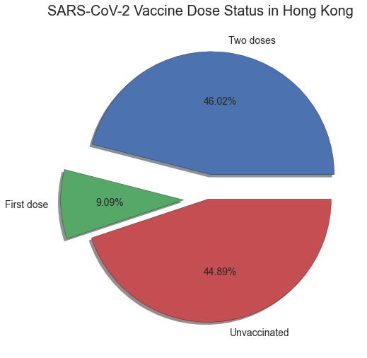

```python
# Configure figure style and size
plt.figure(figsize=(12,8))

slices = [pct_com_vac, pct_vac-pct_com_vac, 1-pct_vac]
labels = ['Two doses','First dose','Unvaccinated']
plt.pie(slices, labels=labels,wedgeprops={'edgecolor':'black'}, shadow=True, explode=(0.2,0.2,0),  autopct='%.2f%%',textprops={'fontsize': 14})
plt.suptitle('SARS-CoV-2 Vaccine Dose Status in Hong Kong',fontsize=20)
plt.show()
```

## Cross-validation of multiple datasets

Sometimes, we may have multiple data tables which contain different information. But they can be related through a specific column. In this case, we can apply [pandas.DataFrame.merge](https://pandas.pydata.org/docs/reference/api/pandas.DataFrame.merge.html) to merge those data tables. In our cases, two datasets are related by 'date' and 'As of date' columns. Therefore, can merge two data sources and perform cross-validate the number of cases record in two datasets.

```python
df_hk_covid_all = df_hk_vac.merge(df_hk_covid,left_on="date",right_on='As of date',how="inner")
```

In the previous cell, we merged data table 'df_hk_vac' and 'df_hk_covid' by 'data' and 'As of date'. We specified how="inner" to perform inner joint which means that only rows that appear in both tables are preserved.

```python
df_hk_covid_all.info()
```

```
<class 'pandas.core.frame.DataFrame'>
Int64Index: 588 entries, 0 to 587
Data columns (total 22 columns):
 #   Column                                                Non-Null Count  Dtype
---  ------                                                --------------  -----
 0   date                                                  588 non-null    datetime64[ns]
 1   total_cases                                           588 non-null    float64
 2   new_cases                                             588 non-null    float64
 3   total_vaccinations                                    588 non-null    float64
 4   people_vaccinated                                     588 non-null    float64
 5   people_fully_vaccinated                               588 non-null    float64
 6   population                                            588 non-null    float64
 7   people_unvaccinated                                   588 non-null    float64
 8   pct_vaccinated                                        588 non-null    float64
 9   pct_fully_vaccinated                                  588 non-null    float64
 10  As of date                                            588 non-null    datetime64[ns]
 11  As of time                                            179 non-null    object
 12  Number of confirmed cases                             588 non-null    int64
 13  Number of ruled out cases                             74 non-null     float64
 14  Number of cases still hospitalised for investigation  74 non-null     float64
 15  Number of cases fulfilling the reporting criteria     74 non-null     float64
 16  Number of death cases                                 588 non-null    int64
 17  Number of discharge cases                             588 non-null    int64
 18  Number of probable cases                              588 non-null    int64
 19  Number of hospitalised cases in critical condition    514 non-null    float64
 20  Number of daily confirmed cases                       588 non-null    int32
 21  Number of active cases                                588 non-null    int64
dtypes: datetime64[ns](2), float64(13), int32(1), int64(5), object(1)
memory usage: 103.4+ KB
```

As a result, the merged data table has 22 columns from both data tables. There are 588 rows appear in both datasets. Then we select the number of cases from two data sources:

```python
# Total cases
cases_gov = df_hk_covid_all['total_cases']
cases_world = df_hk_covid_all['Number of confirmed cases']
# Daily cases
daily_gov = df_hk_covid_all['new_cases']
daily_world = df_hk_covid_all['Number of daily confirmed cases']
```

Here, we calculated the proportion of consensus of total cases in two data sets as follows:

```python
sum(cases_gov == cases_world)/len(df_hk_covid_all)
```

```
0.9030612244897959
```

```python
sum(daily_gov == daily_world)/len(df_hk_covid_all)
```

```
0.8673469387755102
```

We can see that only around 90% and 87% of total cases and daily cases are consistent across datasets. We draw a scatter plot to indicate the inconsistency of two datasets:

[figure not shown]

```python
# Configure figure style and size
plt.figure(figsize=(8,8))
# Plot the figure
plt.scatter(daily_gov, daily_world, edgecolor='black', alpha=.3)
# Plot legends, axis and titles
plt.xlabel('Cases from DATA.GOV.HK',fontsize=16)
plt.ylabel('Cases from Our World Data',fontsize=16)
plt.xticks(fontsize=14)
plt.yticks(fontsize=13)
plt.suptitle('Daily SARS-CoV-2 Active Cases in Hong Kong from two datasets',fontsize=20)
plt.show()
```